# Detection processing report

Written by processing_report() from the processing log and the tables of one detection set. Every number below is read from them.

**Written (UTC)**

2026-11-10 02:57:12

**detqc version**

0.1.1

**Detection set created (UTC)**

2026-11-10 02:57:07

**Coordinate reference system, EPSG code**

4326 (geographic, not projected)

**Logged steps**

11

## Summary

- 3,297 detections came in at the first logged step, detset, which left 4 animals; 1,938 detections of 4 animals remain after 11 logged steps.
- 1,359 detections were removed in 3 steps, for 3 distinct reasons. Largest first: 1,210 after_death_date (filter_mortality, 38.4% of 3,148); 106 post_release_window (filter_post_release, 3.2% of 3,297); 43 isolated (filter_min_lag, 1.3% of 3,191).
- 1 of 30 data-entry checks flagged rows; checks not run: 8.
- 180 receiver-days at 20 stations, by the status audit_listening() gave them: 77 listening (detections heard), 103 silent (nothing heard and no reference tag to show the receiver worked). The audit counts 180 of these receiver-days as listening, silent days included, and 0 as not listening (not_downloaded, reference_silent, silent_run).
- 1 of 4 animals is in the dead band and 3 in the review band.
- Reviewer calls are applied for 4 animals, 1 of them dead_or_shed.

## What came in

At the first logged step, record 1 (detset), 3,297 detections came in, naming 4 animals; the step left 4 animals.

Rows read by the import functions, from record 1 of the log, against the rows they kept after any cut: detections: 3,297 rows read from 1 file, 3,297 kept; deployments: 20 rows read from 1 file, 20 kept; animals: 3,297 rows read from 1 file, 4 kept.

Files read into the detection set, one row per file. Rows kept counts the rows each read function kept, after any cut; the rows read from each file are in attr(, "source") of the table the read function returned.

| Table | File | Format | Rows kept |
| --- | --- | --- | --- |
| detections | stoney_detections.csv | glatos | 3,297 |
| deployments | stoney_receivers.csv | glatos | 20 |
| animals | stoney_detections.csv | glatos | 4 |

deployments, 20 rows kept by the read function and 20 in the detection set; animals, 4 rows kept by the read function and 4 in the detection set. Rows kept by the read functions but not in the set were cut before detset() was called, or set aside by it; record 1 counts what detset() set aside.

### The tables after the last logged step

Rows and distinct values in each table of the detection set after the last logged step. Listening rows are receiver-days; the last deployment date is the latest recovery.

| Table | Rows | Animals | Transmitters | Receivers | Stations | First (UTC) | Last (UTC) |
| --- | --- | --- | --- | --- | --- | --- | --- |
| detections | 1,938 | 4 | 4 | 14 | 14 | 2024-06-02 21:31:55 | 2024-06-10 11:58:21 |
| deployments | 20 |  |  | 20 | 20 | 2024-06-01 14:00:00 | 2024-06-11 15:00:00 |
| listening | 180 |  |  | 20 | 20 | 2024-06-02 | 2024-06-10 |
| animals | 4 | 4 | 4 |  |  |  |  |

## Processing steps

One row per logged step, in order. Added or lost counts detections that changed with no logged reason: above zero, rows were added, which only a load step may do; below zero, rows were lost. Per cent retained is detections after over detections before. A flagged row breaks the log's arithmetic; the summary says how. Under each name: the kind of step (load, check, filter, mortality or other) and, when it differs from the name, the function that ran it.

| Step | Name and kind | Detections before | Removed | Added or lost | Detections after | Per cent retained | Animals before | Animals after |
| --- | --- | --- | --- | --- | --- | --- | --- | --- |
| 1 | detset load | 3,297 | 0 | 0 | 3,297 | 100.0 | 4 | 4 |
| 2 | calibrate_sensors other | 3,297 | 0 | 0 | 3,297 | 100.0 | 4 | 4 |
| 3 | check_detset check | 3,297 | 0 | 0 | 3,297 | 100.0 | 4 | 4 |
| 4 | audit_listening check | 3,297 | 0 | 0 | 3,297 | 100.0 | 4 | 4 |
| 5 | filter_duplicates filter | 3,297 | 0 | 0 | 3,297 | 100.0 | 4 | 4 |
| 6 | filter_post_release filter | 3,297 | 106 | 0 | 3,191 | 96.8 | 4 | 4 |
| 7 | filter_min_lag filter | 3,191 | 43 | 0 | 3,148 | 98.7 | 4 | 4 |
| 8 | detect_mortality mortality | 3,148 | 0 | 0 | 3,148 | 100.0 | 4 | 4 |
| 9 | build_mortality_cards mortality | 3,148 | 0 | 0 | 3,148 | 100.0 | 4 | 4 |
| 10 | apply_mortality_calls mortality | 3,148 | 0 | 0 | 3,148 | 100.0 | 4 | 4 |
| 11 | filter_mortality mortality | 3,148 | 1,210 | 0 | 1,938 | 61.6 | 4 | 4 |

**Parameters and notes of each step**

The notes are the step's own text: numbers inside them are not checked against the counts.

| Step | Logged at (UTC) | Parameters | What the step recorded, in its own words |
| --- | --- | --- | --- |
| 1 | 2026-11-10 02:57:07 | crs = 4326L; tz = "UTC"; deployments = 20L; animals = 4L; rows_read = c(detections = 3297L, deployments = 20L, animals = 3297L) | station from a deployment for 3,297 of 3,297 detections (half-open intervals); 0 of them matched on the bare receiver serial and 0 on station_id to a deployment with no receiver serial; 0 matched none… |
| 2 | 2026-11-10 02:57:07 | specs = "none"; overwrite = FALSE | 1,736 of 1,736 raw sensor readings calibrated (0 with a calibration from specs); kept, with a sensor_value already: 0; with a calibration but no unit: 0; with no calibration: 0 (0 transmitters); not w… |
| 3 | 2026-11-10 02:57:10 | checks = c("coordinate_units", "swapped_lat_lon", "wrong_sign", "outside_extent", "on_land", "station_coordinates", "station_reused", "overlapping_deployments", "recover_before_deploy", "deploy_year_o… | 30 checks: 1 flagged, 21 passed, 8 not run; flagged: receiver_silent |
| 4 | 2026-11-10 02:57:10 | reference_tags = NULL; min_share = 0.5; max_silent_days = NULL; known_listening = c("R001", "R002", "R003", "R004", "R005", "R006", "R007", "R008", "R009", "R010") ... (20 values) | 180 receiver-days of 20 receivers: 77 listening, 0 partial, 103 silent, 0 reference_missed, 0 reference_silent, 0 silent_run, 0 not_downloaded; 0 reference tags, 0 expected receiver pairs; 54 silent_r… |
| 5 | 2026-11-10 02:57:10 | by = c("datetime", "receiver_serial", "transmitter"); tolerance_s = 0 | removed 0 of 3,297 detections (0%); 0 animals lost every detection |
| 6 | 2026-11-10 02:57:10 | hours = 6 | removed 106 of 3,297 detections (3.22%); 0 animals lost every detection |
| 7 | 2026-11-10 02:57:10 | max_lag_s = 4500; min_lag_s = 0 | removed 43 of 3,191 detections (1.35%); 0 animals lost every detection |
| 8 | 2026-11-10 02:57:11 | sites_km = 1; site_distance = "straight-line"; sparse_to_review = TRUE; horizon = "2024-06-10 11:58:21 UTC"; accel_flatline = "(accel_flat = 0.1; min_flat_days = 2; active_within_days = 30; min_readin… | 4 animals sorted by 7 rule streams: dead 1, review 3, alive 0; sites of at most 1 km (20 sites); with no located detection: 0 animals; 0 of 0 accelerometers raw, with no sensor vote; 0 animals with de… |
| 9 | 2026-11-10 02:57:11 | which = c("dead", "review", "alive"); dir = "mortality_review" | 4 cards written (dead 1, review 3, alive 0) for 4 animals in the bands (dead 1, review 3, alive 0); read back from their HTML equal to the detset, the animals table and the bands on 18 quantities each… |
| 10 | 2026-11-10 02:57:11 | file=mortality_calls.csv; md5=3021ab8b2a329322d7707d0357e2d1c3 | 4 calls read: 3 alive, 1 dead_or_shed, 0 uncertain; 0 death dates dropped from alive calls; 0 dead_or_shed calls with no date; 0 death dates before the first detection; no candidate_date column; 0 row… |
| 11 | 2026-11-10 02:57:11 | calls=4; margin_days=1; rule=datetime > death_time - margin, else date > death_date - margin | 1,210 detections of 1 animal called dead_or_shed removed after each death time less a margin of 1 day, or from the UTC day after the death date less the margin for a date with no time (1 call with a t… |

## Data-entry checks

### Receivers

| Check | Status | Flagged | Of | Counting | Note |
| --- | --- | --- | --- | --- | --- |
| coordinate_units | pass | 0 | 20 | deployments | positions missing or not in decimal degrees, as projected metres would be |
| swapped_lat_lon | pass | 0 | 20 | deployments | swapping latitude and longitude brings each inside the extent |
| wrong_sign | pass | 0 | 20 | deployments | changing the sign of latitude or longitude brings each inside |
| outside_extent | pass | 0 | 20 | deployments | further than max(20 km, 10 x the median spread) from the median deployment and not explained by a swap or a sign |
| on_land | pass | 0 | 20 | deployments | 0 positions off the water layer not checked; 0 left to the position checks |
| station_coordinates | pass | 0 | 20 | deployments | coordinate sets 100 to 1000 m apart, or stations within 10 m |
| station_reused | pass | 0 | 20 | deployments | one station name at places more than 1000 m apart |
| overlapping_deployments | pass | 0 | 20 | deployments | deployments of one receiver serial overlap in time |
| recover_before_deploy | pass | 0 | 20 | deployments | 0 more are a year off and reported by deploy_year_off |
| deploy_year_off | pass | 0 | 20 | deployments | a gap of 300 days or more between a deployment end and its detections, or a one-year shift that covers the receiver's orphan detections |
| recover_after_download | not run | – | – | deployments | the deployments have no `download_datetime` |
| detections_after_download | not run | – | – | deployments | the deployments have no `download_datetime` |
| depth_below_bottom | pass | 0 | 20 | deployments | receiver deeper than the bathymetry by more than 1 m; 0 with no depth there |
| serial_not_deployed | pass | 0 | 3,297 | detections | 0 receiver serials appear in no deployment |
| receiver_silent | flag | 6 | 20 | deployments | deployments that hold no detection of any transmitter, of those that overlap the detections' time span by a day or more |
| moved_mooring | not run | – | – | deployments | nothing to test, the denominator is 0; partner shares before and after a date differ by a total variation distance of 0.75 or more; 0 flagged on reference-tag co-detections and 0 on animal co-detectio… |

**Offending rows of receiver_silent: 6 shown of 6**

| receiver_serial | station_id | deploy_datetime | recover_datetime | deploy_lat | deploy_lon | deploy_z | receiver_model | consecutive_deploy_no | intend_lat | intend_long | recover_lat | recover_long | bottom_depth | riser_length | glatos_ins_frequency | code_map | code_map_comment | deployed_by | comments | glatos_seasonal | glatos_project | glatos_vps | recovery_status | deployment |
| --- | --- | --- | --- | --- | --- | --- | --- | --- | --- | --- | --- | --- | --- | --- | --- | --- | --- | --- | --- | --- | --- | --- | --- | --- |
| R015 | S015 | 2024-06-01 14:00:00 | 2024-06-11 15:00:00 | 44.57059 | -78.08253 | 1.67 | VR2Tx | 1 | – | – | – | – | 1.67 | – | 69 | – | – | – | – | – | STN | – | – | 15 |
| R016 | S016 | 2024-06-01 14:00:00 | 2024-06-11 15:00:00 | 44.57017 | -78.06618 | 24.83 | VR2Tx | 1 | – | – | – | – | 24.83 | – | 69 | – | – | – | – | – | STN | – | – | 16 |
| R017 | S017 | 2024-06-01 14:00:00 | 2024-06-11 15:00:00 | 44.56975 | -78.04983 | 7.24 | VR2Tx | 1 | – | – | – | – | 7.24 | – | 69 | – | – | – | – | – | STN | – | – | 17 |
| R018 | S018 | 2024-06-01 14:00:00 | 2024-06-11 15:00:00 | 44.58138 | -78.08199 | 6.51 | VR2Tx | 1 | – | – | – | – | 6.51 | – | 69 | – | – | – | – | – | STN | – | – | 18 |
| R019 | S019 | 2024-06-01 14:00:00 | 2024-06-11 15:00:00 | 44.58096 | -78.06563 | 2.87 | VR2Tx | 1 | – | – | – | – | 2.87 | – | 69 | – | – | – | – | – | STN | – | – | 19 |
| R020 | S020 | 2024-06-01 14:00:00 | 2024-06-11 15:00:00 | 44.58054 | -78.04928 | 8.94 | VR2W | 1 | – | – | – | – | 8.94 | – | 69 | – | – | – | – | – | STN | – | – | 20 |

### Animals and tags

| Check | Status | Flagged | Of | Counting | Note |
| --- | --- | --- | --- | --- | --- |
| transmitter_no_animal | pass | 0 | 4 | transmitters | reference tags count as unknown unless given in `reference_tags`; rows sorted by detections, most first |
| animal_never_heard | pass | 0 | 4 | animals | animals with no detection of any of their transmitters |
| before_release | pass | 0 | 3,297 | detections | detections before the animal's earliest release |
| after_tag_life | pass | 0 | 3,297 | detections | detections after release plus tag_life_days |
| long_after_release | not run | – | – | detections | give check_settings(max_liberty_years = ), the longest life in years of the study's tag models |
| reappeared_elsewhere | pass | 0 | 4 | transmitters | silent more than 365 days, then heard only at stations not used before |
| animal_conflict | pass | 0 | 4 | animals | animals with two values of species, length |
| duplicate_animal_id | pass | 0 | 4 | animals | animal ids on two release records, a transmitter twice or a repeated row |

### Time

| Check | Status | Flagged | Of | Counting | Note |
| --- | --- | --- | --- | --- | --- |
| non_utc | not run | – | – | deployments | nothing to test, the denominator is 0; detections up to 0 h outside the ends of 0 of 0 deployments active near them; 0 of 0 deployments detecting near the other end detect inside the offset |
| dst_jump | not run | – | – | receivers | 14 of 14 receivers have rows in time order, which a table sorted by time also gives, and 0 have steps back that no clock jump explains, so their rows are not in the order logged; a jump forward, and a… |
| outside_deployment | pass | 0 | 3,297 | detections | 0 more are explained by a year off, a time-zone offset or a bad recovery date |
| duplicate_rows | pass | 0 | 3,297 | detections | copies of a row with the same time, receiver and transmitter |

### Against the detection field

| Check | Status | Flagged | Of | Counting | Note |
| --- | --- | --- | --- | --- | --- |
| codetection_out_of_range | not run | – | – | co-detections | no `field` supplied |
| reference_position | not run | – | – | detections | no `field` supplied |

## Receiver listening

Receiver-days by the status audit_listening() gave them.

| Status | Receiver-days | Of |
| --- | --- | --- |
| listening | 77 | 180 |
| silent | 103 | 180 |

**Receiver-days per station, 20 stations**

| Station | Receivers | Receiver-days | First | Last |
| --- | --- | --- | --- | --- |
| S001 | 1 | 9 | 2024-06-02 | 2024-06-10 |
| S002 | 1 | 9 | 2024-06-02 | 2024-06-10 |
| S003 | 1 | 9 | 2024-06-02 | 2024-06-10 |
| S004 | 1 | 9 | 2024-06-02 | 2024-06-10 |
| S005 | 1 | 9 | 2024-06-02 | 2024-06-10 |
| S006 | 1 | 9 | 2024-06-02 | 2024-06-10 |
| S007 | 1 | 9 | 2024-06-02 | 2024-06-10 |
| S008 | 1 | 9 | 2024-06-02 | 2024-06-10 |
| S009 | 1 | 9 | 2024-06-02 | 2024-06-10 |
| S010 | 1 | 9 | 2024-06-02 | 2024-06-10 |
| S011 | 1 | 9 | 2024-06-02 | 2024-06-10 |
| S012 | 1 | 9 | 2024-06-02 | 2024-06-10 |
| S013 | 1 | 9 | 2024-06-02 | 2024-06-10 |
| S014 | 1 | 9 | 2024-06-02 | 2024-06-10 |
| S015 | 1 | 9 | 2024-06-02 | 2024-06-10 |
| S016 | 1 | 9 | 2024-06-02 | 2024-06-10 |
| S017 | 1 | 9 | 2024-06-02 | 2024-06-10 |
| S018 | 1 | 9 | 2024-06-02 | 2024-06-10 |
| S019 | 1 | 9 | 2024-06-02 | 2024-06-10 |
| S020 | 1 | 9 | 2024-06-02 | 2024-06-10 |

## Detections removed, by reason

One row per step and reason. The reason no_breakdown marks a step that logged one total.

| Step | Name | Reason | Detections removed | Of, before the step | Per cent |
| --- | --- | --- | --- | --- | --- |
| 6 | filter_post_release | post_release_window | 106 | 3,297 | 3.2 |
| 7 | filter_min_lag | isolated | 43 | 3,191 | 1.3 |
| 11 | filter_mortality | after_death_date | 1,210 | 3,148 | 38.4 |

## Mortality

Mortality bands from detect_mortality(), one per animal with a detection. A person decides each animal on the review pages.

| Band | Animals | Of |
| --- | --- | --- |
| dead | 1 | 4 |
| review | 3 | 4 |
| alive | 0 | 4 |

Animals per band and the rule that decided the band.

| Band | Deciding rule | Animals |
| --- | --- | --- |
| dead | terminal_run | 1 |
| review | record_end | 2 |
| review | terminal_run_stray | 1 |

Reviewer calls applied by apply_mortality_calls().

| Call | Animals | Of |
| --- | --- | --- |
| alive | 3 | 4 |
| dead_or_shed | 1 | 4 |
| uncertain | 0 | 4 |

Dead_or_shed calls with a death date: 1.

The review cards: open the card index, where a person makes the call on each animal.

## Figures

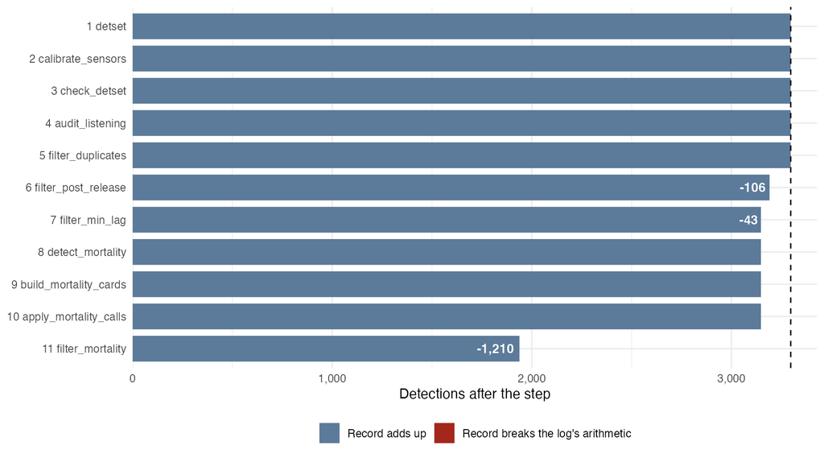

**attrition.** Attrition ladder: detections left after each of 11 logged steps, one bar per log record, in order from the top, labelled with the record number and step. The dashed line marks the 3,297 detections that came in at the first step; 1,938 remain after the last. Records that break the log's arithmetic, as the key marks them: 0.

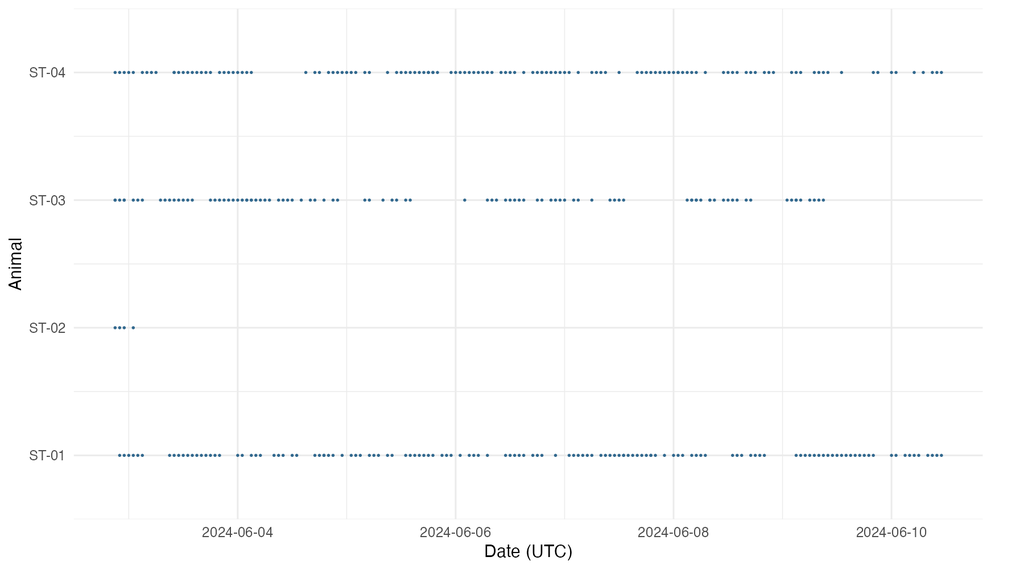

**abacus.** Detections over time, one point per animal, station and hour: 1,938 detections, 2024-06-02 21:31:55 to 2024-06-10 11:58:21 (UTC), on 4 rows. Animals take 4 of the rows, 0 of them tagged animals released inside this span with no detection, marked (none); transmitters of detections with no animal, such as reference tags, take 0, labelled by code. Tagged animals with no detection released outside this span are not drawn: 0. Triangles mark releases.

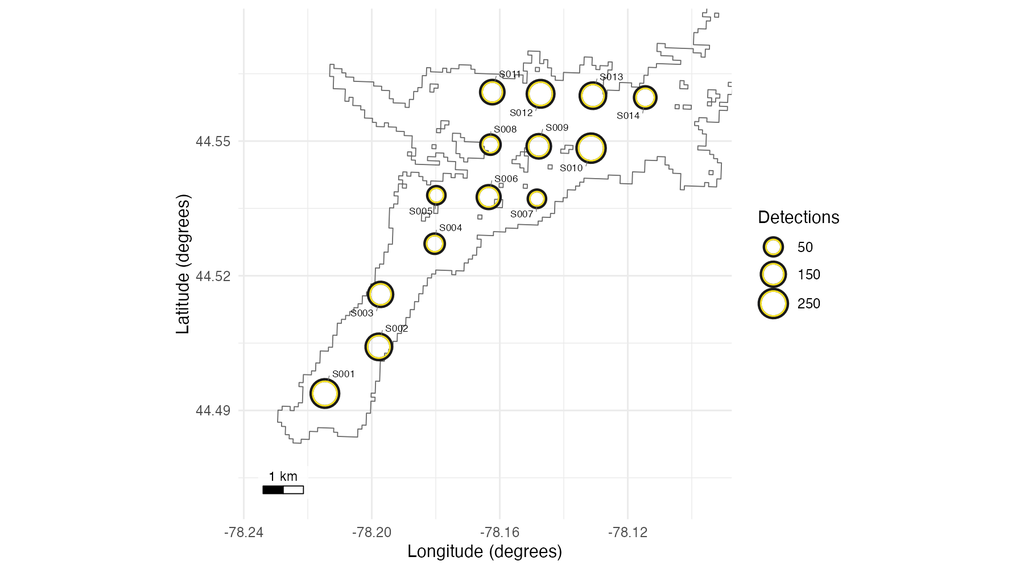

**receivers.** Receiver stations and the detections at each: 20 stations of 20 deployments, 1,938 detections. The map is fitted to the 14 stations that heard a detection, and only they are named; open circles heard nothing, and stations outside the map are not drawn. Scale bar length in metres or kilometres, as labelled.

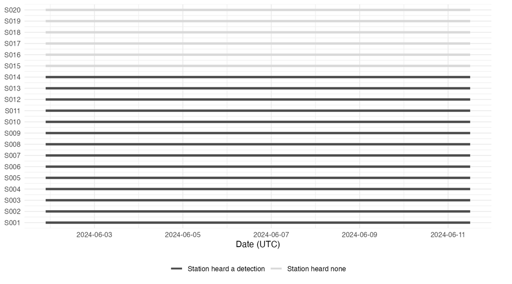

**timeline.** Receiver deployments over time: 20 deployments of 20 receivers, 180 receiver-days; audit_listening() counts all 180 as listening, silent days included, so the figure has no ticks. The time axis covers the detections, deployments outside it are not drawn, and stations are in natural order.

## Session information

R and the packages detqc imports, in the session that wrote this report.

| Item | Version |
| --- | --- |
| R | R version 4.2.1 (2022-06-23) |
| Platform | aarch64-apple-darwin20 |
| Operating system | macOS 15.7.7 |
| detqc | 0.1.1 |
| data.table | 1.18.2.1 |
| jsonlite | 2.0.0 |
| lubridate | 1.9.5 |